# Home Field Advantage

Yiwen Chen

10/2/2021

## Introduction

**If home field advantage exists, how much of an impact does it have on winning the world series?**

The World Series is a first-to-4-wins match-up between the champions of the American and National Leagues of Major League Baseball. I am going to use simulation and analytic methods to compare the probability of winning the World Series with and without home field advantage. And at the same time, I will explain the solution and my assumptions of solutions in data science concepts, which may help our general audience to figure out the question above.

**PS:**

**Home field advantage:** The edge a team may have when playing a game at its home stadium. For example, it is the edge the Braves may have over the Yankees when the head-to-head match-up is in Atlanta. It is the advantage the Yankees may have when the head-to-head match-up is in New York.

## Background

### Setup

To help our audience to figure out this topic easily:

**1.** I set up that **Braves** and **Yankees** are teams competing in the World Series.

**2.** I set up the table below that has two possible schedules for each game of this series.(NYC = New York City, ATL = Atlanta)

| **Overall Advantage** | **Game 1** | **Game 2** | **Game 3** | **Game 4** | **Game 5** | **Game 6** | **Game 7** |
| --- | --- | --- | --- | --- | --- | --- | --- |
| Braves | ATL | ATL | NYC | NYC | NYC | ATL | ATL |
| Yankees | NYC | NYC | ATL | ATL | ATL | NYC | NYC |

Let **P<sub>B</sub>** be the probability that the Braves win a single head-to-head match-up with the Yankees, under the assumption that home field advantage doesn’t exist. Let **P<sub>BH</sub>** denote the probability that the Braves win a single head-to-head match-up with the Yankees as the home team (H for home). Let **P<sub>BA</sub>** denote the probability that the Braves win a single head-to-head match-up with the away team (A for away).

| **Game location** | **No advantage** | **Advantage** |
| --- | --- | --- |
| ATL | P<sub>B</sub> | P<sub>BH</sub> = P<sub>B</sub>*1.1 |
| NYC | P<sub>B</sub> | P<sub>BA</sub> = 1−(1−P<sub>B</sub>)*1.1 |

### Question

**1.** Compute analytically the probability that the Braves win the world series when the sequence of game locations is {NYC, NYC, ATL, ATL, ATL, NYC, NYC}. Calculate the probability with and without home field advantage when P<sub>B</sub>=0.55. What is the difference in probabilities?

**2.** Calculate the same probabilities as the previous question by simulation.

**3.** What is the absolute and relative error for your simulation in the previous question?

**4.** Does the difference in probabilities (with vs without home field advantage) depend on P<sub>B</sub>?

**5.** Does the difference in probabilities (with vs without home field advantage) depend on the advantage factor?

## Question 1

Firstly, I `library` packages and import the data.

```r
library(dplyr)
library(data.table)
```

```r
library(ggplot2)
# Get all possible outcomes
apo <- fread("all-possible-world-series-outcomes.csv")
```

Then, I set up a function to calculate the probability of each possible outcome and sum up the probability of the Braves win the world series. In this function, I set 1 as game played in ATL, 0 as game played in NYC and the `hfi` as the sequence of 1 and 0. The `pb` is P<sub>B</sub> and the `advantage_multiplier` is the home field advantage coefficient(1 or 1.1).

```r
#default setting:
#hfi <- c(1,1,0,0,0,1,1) = {ATL, ATL, NYC, NYC, NYC, ATL, ATL}
#hfi <- c(0,0,1,1,1,0,0) = {NYC, NYC, ATL, ATL, ATL, NYC, NYC}

default_setting <- function(hfi, pb, advantage_multiplier){
# P_B
  pbh <- pb * advantage_multiplier
  pba <- 1 - (1 - pb) * advantage_multiplier
# Calculate the probability of each possible outcome
  apo[, p := NA_real_] # Initialize new column in apo to store prob
  for(i in 1:nrow(apo)){
    prob_game <- rep(1, 7)
    for(j in 1:7){
      p_win <- ifelse(hfi[j], pbh, pba)
      prob_game[j] <- case_when(
        apo[i,j,with=FALSE] == "W" ~ p_win
      , apo[i,j,with=FALSE] == "L" ~ 1 - p_win
      , TRUE ~ 1
    )
  }
  apo[i, p := prod(prob_game)] # Data.table syntax
}

# Sanity check: does sum(p) == 1?
apo[, sum(p)] # This is data.table notation

# Probability of overall World Series outcomes
apo[, sum(p), overall_outcome]
}
```

### With Home Field Advantages

I would use the function `default_setting` with `hfi=c(0,0,1,1,1,0,0)`, `pb=0.55`, `advantage_multiplier=1.1` to get the answer, the probability of Braves winning the world series with home field advantages.

```r
ana_with_hfa <- default_setting(hfi=c(0,0,1,1,1,0,0), pb=0.55, advantage_multiplier=1.1)
ana_with_hfa
```

```
##    overall_outcome       V1
## 1:               W 0.604221
## 2:               L 0.395779
```

The answer is **0.604221**.

### Without Home Field Advantages

I would use the function `default_setting` with `hfi=c(0,0,1,1,1,0,0)`, `pb=0.55`, `advantage_multiplier=1` to get the answer, the probability of Braves winning the world series without home field advantages.

```r
ana_without_hfa <- default_setting(hfi=c(0,0,1,1,1,0,0), pb=0.55, advantage_multiplier=1)
ana_without_hfa
```

```
##    overall_outcome        V1
## 1:               W 0.6082878
## 2:               L 0.3917122
```

The answer is **0.6082878**.

### The Difference in Probabilities

```r
ana_with_hfa$V1 - ana_without_hfa$V1
```

```
## [1] -0.004066825  0.004066825
```

I get the difference of those 2 probabilities is **-0.004066825**

### Conclusion

If home field advantage exists, the probability of Braves winning the world series would decrease. Because in the `default setting` the sequence of game locations is {NYC, NYC, ATL, ATL, ATL, NYC, NYC}, which means Braves only has 3 home field games(away field games is 4).

## Question 2

I set up a function with 2 forloops. The 1st forloop is to calculate the result of a first-to-4-wins match-up. In this forloop, it would return a possible result for World Series randomly. And then, since the 1st forloop would randomly return a TRUE or FALSE result, I set up another forloop to calculate its mean after getting 10000 results. And the result of this forloop would be the probability of the Braves winning the world series.

```r
default_setting_simu <-function(times, hfi, pb, advantage_multiplier){
  simu_with_hfa = NA
  world_series = NA
  for(j in 1:times){
  pbh <- pb * advantage_multiplier
  pba <- 1 - (1 - pb) * advantage_multiplier
  sum_win_game = 0
  for(i in 1:7){
    if(hfi[i]){
               pb_win = pbh
               }
      else{
           pb_win = pba
           }
    win_or_lose = rbinom(1,1,pb_win)
    sum_win_game = win_or_lose + sum_win_game
    if(sum_win_game == 4|(i - sum_win_game)== 4)
      break
  }

  world_series <- (sum_win_game == 4)
  simu_with_hfa[j] = world_series
}
  return(mean(simu_with_hfa))
}
```

### With Home Field Advantages

The probability of Braves winning the world series with home field advantages is:

```r
simu_with_hfa <- default_setting_simu(times = 10000,hfi=c(0,0,1,1,1,0,0),pb=0.55,advantage_multiplier=1.1)
simu_with_hfa
```

```
## [1] 0.6036
```

### Without Home Field Advantages

The probability of Braves winning the world series without home field advantages is:

```r
simu_without_hfa <- default_setting_simu(times = 10000,hfi=c(0,0,1,1,1,0,0),pb=0.55,advantage_multiplier=1)
simu_without_hfa
```

```
## [1] 0.6129
```

### The Difference in Probabilities

```r
simu_with_hfa-simu_without_hfa
```

```
## [1] -0.0093
```

### Conclusion

If home field advantage exists, the probability of Braves winning the world series from the simulation would decrease. And the results are very close to the analytic.

## Question 3

Absolute Error = |p-hat - p|

Relative Error = |p-hat - p|/p

`p-hat` is the answer we get from the simulation, and `p` is the answer we get from the analytic.

### Absolute Error

The Absolute Error with the assumption that Braves win the World Series with home field advantage is:

```r
abs(simu_with_hfa - ana_with_hfa$V1[1])
```

```
## [1] 0.0006209716
```

The Relative Error with the assumption that Braves win the World Series with home field advantage is:

```r
abs(simu_with_hfa - ana_with_hfa$V1[1])/ana_with_hfa$V1[1]
```

```
## [1] 0.001027723
```

The Absolute Error with the assumption that Braves win the World Series without home field advantage is:

```r
abs(simu_without_hfa - ana_without_hfa$V1[1])
```

```
## [1] 0.004612203
```

The Relative Error with the assumption that Braves win the World Series without home field advantage is:

```r
abs(simu_without_hfa - ana_without_hfa$V1[1])/ana_without_hfa$V1[1]
```

```
## [1] 0.007582271
```

## Question 4

I set P<sub>B</sub> from 0.5 to 0.99 in the analytically probability code chunk, to figure out how the difference in probabilities of Braves win the world series change depends on P<sub>B</sub>.

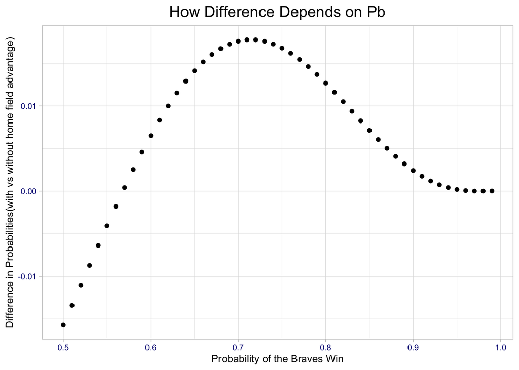

```r
#setting
pb <- seq(0.5,0.99,0.01)
pb_with_hfa <- rep(NA, length(pb))
pb_without_hfa <- rep(NA, length(pb))
pb_diff <- rep(NA, length(pb))
advantage_multiplier <- 1.1
hfi <- c(0,0,1,1,1,0,0)

for (k in seq_along(pb)) {
  pbh <- pb[k] * advantage_multiplier
  pba <- 1 - (1 - pb[k]) * advantage_multiplier
  pb_without_hfa[k] <- pnbinom(3, 4, pb[k])
  # Calculate the probability of each possible outcome
apo[, p := NA_real_] # Initialize new column in apo to store prob
for(i in 1:nrow(apo)){
  prob_game <- rep(1, 7)
  for(j in 1:7){
    p_win <- ifelse(hfi[j], pbh, pba)
    prob_game[j] <- case_when(
        apo[i,j,with=FALSE] == "W" ~ p_win
      , apo[i,j,with=FALSE] == "L" ~ 1 - p_win
      , TRUE ~ 1
    )
  }
  apo[i, p := prod(prob_game)] # Data.table syntax
  }
  pb_with_hfa[k] <- unlist(apo[, sum(p), overall_outcome][1][,2])
  pb_diff[k] <- pb_with_hfa[k] - pb_without_hfa[k]
}

df4 <- data.frame(pb,pb_diff)
ggplot(df4,
       aes(x = pb,
           y = pb_diff)
       ) +
   geom_point() +
   labs(
        x="Probability of the Braves Win",
        y="Difference in Probabilities(with vs without home field advantage)",
        title="How Difference Depends on Pb") +
   theme_bw() +
   theme_light()+
   theme(
        axis.title = element_text(size = 10),
        plot.title = element_text(hjust = 0.5, size = 15),
        axis.text = element_text(size = 8, color = "Navy"))
```

In the plot, the difference increases from 0.5 to 0.7, then graudally decreases from 0.7 to 0.99 and infinitely closes to 0. And when P<sub>B</sub> is from 0.5 to approximately 0.57, the difference in probabilities is negative, and then the difference become positive.

## Question 5

I set `advantage_multiplier` from 1 to 1.99 in the analytically probability code chunk, to figure out how the difference in probabilities of Braves win the world series change depends on `advantage_multiplier`.

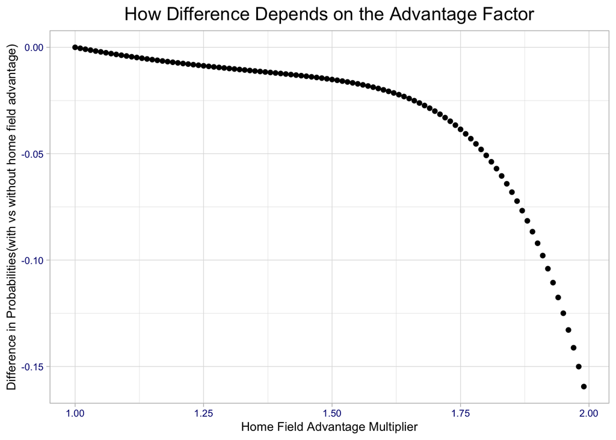

```r
#setting
advantage_multiplier <- seq(1,1.99,0.01)
pb_with_hfa <- rep(NA, length(advantage_multiplier))
pb_without_hfa <- rep(NA, length(advantage_multiplier))
pb_diff <- rep(NA, length(advantage_multiplier))
pb <- 0.55
hfi <- c(0,0,1,1,1,0,0)

for (k in seq_along(advantage_multiplier)) {
  pbh <- pb * advantage_multiplier[k]
  pba <- 1 - (1 - pb) * advantage_multiplier[k]
  pb_without_hfa[k] <- pnbinom(3, 4, pb)

  # Calculate the probability of each possible outcome
apo[, p := NA_real_] # Initialize new column in apo to store prob
for(i in 1:nrow(apo)){
  prob_game <- rep(1, 7)
  for(j in 1:7){
    p_win <- ifelse(hfi[j], pbh, pba)
    prob_game[j] <- case_when(
        apo[i,j,with=FALSE] == "W" ~ p_win
      , apo[i,j,with=FALSE] == "L" ~ 1 - p_win
      , TRUE ~ 1
    )
  }
  apo[i, p := prod(prob_game)] # Data.table syntax
  }
  pb_with_hfa[k] <- unlist(apo[, sum(p), overall_outcome][1][,2])
  pb_diff[k] <- pb_with_hfa[k] - pb_without_hfa[k]
}

df5 <- data.frame(advantage_multiplier,pb_diff)
ggplot(df5,
       aes(x = advantage_multiplier,
           y = pb_diff)) +
   geom_point() +
   labs(
        x="Home Field Advantage Multiplier",
        y="Difference in Probabilities(with vs without home field advantage)",
        title="How Difference Depends on the Advantage Factor") +
   theme_bw() +
   theme_light() +
   theme(
        axis.title = element_text(size = 10),
        plot.title = element_text(hjust = 0.5, size = 15),
        axis.text = element_text(size = 8, color = "Navy"))
```